# power_analysis

2024-10-14

## Rationale

We’ll be flyering on Sproul Plaza. We interviewed 4 different students who handed out fliers (3 from Triathlon club, 1 from Glamour Girls). None of the people we interviewed wore Berkeley Merch. However, the table / banner design of the Triathlon club was themed with Berkeley colors. We received the following estimates:

5-20 fliers per hour (Glamour Girls) 20-30 fliers per hour (Triathlon) 40-60 fliers per hour (Triathlon) 100 fliers per hour (Triathlon)

Given these numbers, we use a rough conservative estimate of mean: 40 fliers per hour, with a standard deviation of 10 for non-Berkeley, non-Stanford merch.

From other research about clothing effects on donation recruitment (Levine, Bluni, Hochmann 1998), we get 56% donated if dressed preppy, vs 18% if dressed messy. That’s a 3x increase if people dressed preppy. This could be equivalent to wearing Stanford vs Berkeley Merch. However, in a different study where someone dressed up as Santa or not (Osbaldiston & De Boer, 2011), there was no significant difference in donations. A conservative assumption might be a 1.5 times increase between conditions. This is in line with the Triathlon club handing out more fliers than the Glamour Girls (the Triathlon club table ‘gave Berkeley vibes’).

Assuming that the Stanford condition would produce 30 fliers per hour (with std=5), the Berkeley merch condition might then produce a 1.5x increase in fliers, giving us 45 fliers per hour (with std=5).

We’ll be runnning 6 sessions per hour, so dividing the above numbers by 6 results in the following 3 conditions we’ll be testing, accross sample size = 4-40, increasing by 2 at each measurement. We estimate the QR-code scan average to be 1 per session in control/stanford.

#Condition 1: As above Control/Stanford Condition: * 5 fliers per session (std 0.5) * 1 scan per session (std 0.25) Berkeley Condition: * 7.5 fliers per session * 1.5 scans per session

#Condition 2: Lower ATEs Control/Stanford Condition: * 5 fliers per session (std 0.5) * 1 scan per session (std 0.25) Berkeley Condition: * 6 fliers per session * 1.2 scans per session

#Condition 3: Higher Variance Control/Stanford Condition: * 5 fliers per session (std 1) * 1 scan per session (std 0.5) Berkeley Condition: * 7.5 fliers per session * 1.5 scans per session

In the following, we are comparing the Berkeley vs Stanford condition.

## Generating Data

```r
library(ggplot2)
library(data.table)

set.seed(1)

demo_size = 1000
d <- data.table(
  shared_flyers_control = rnorm(demo_size, 5, 0.5 ),
  replies_control = rnorm(demo_size, 1, 0.25),
  treatment = sample(rep(0:1, each = demo_size / 2))
)


d[, shared_flyers_treatment := shared_flyers_control + 2.5 ]
d[, replies_treatment := replies_control + 0.5 ]

#d[, shared_flyers_treatment := shared_flyers_control + rnorm(demo_size, 1, 0.25) ]
#d[, replies_treatment := replies_control + rnorm(demo_size, 0.5, 0.2)  ]

d[, shared_measured := ifelse(treatment == 1, shared_flyers_treatment, shared_flyers_control)]
d[, replies_measured := ifelse(treatment == 1, replies_treatment, replies_control)]

# min all measurements to zero
d[, shared_measured := pmax(shared_measured, 0)]
d[, replies_measured := pmax(replies_measured, 0)]



#Preparing data for Scenario 2
e <- data.table(
  shared_flyers_control = rnorm(demo_size, 5, 0.5 ),
  replies_control = rnorm(demo_size, 1, 0.25),
  treatment = sample(rep(0:1, each = demo_size / 2))
)


e[, shared_flyers_treatment := shared_flyers_control + 1 ]
e[, replies_treatment := replies_control + 0.2  ]

#e[, shared_flyers_treatment := shared_flyers_control + rnorm(demo_size, 0.6, 0.25) ]
#e[, replies_treatment := replies_control + rnorm(demo_size, 0.25, 0.2)  ]

e[, shared_measured := ifelse(treatment == 1, shared_flyers_treatment, shared_flyers_control)]
e[, replies_measured := ifelse(treatment == 1, replies_treatment, replies_control)]

# min all measurements to zero
e[, shared_measured := pmax(shared_measured, 0)]
e[, replies_measured := pmax(replies_measured, 0)]


#Preparing data for Scenario 3: More variance in data
c <- data.table(
  shared_flyers_control = rnorm(demo_size, 5, 1 ),
  replies_control = rnorm(demo_size, 1, 0.5),
  treatment = sample(rep(0:1, each = demo_size / 2))
)


c[, shared_flyers_treatment := shared_flyers_control + 2.5 ]
c[, replies_treatment := replies_control + 0.5  ]

#c[, shared_flyers_treatment := shared_flyers_control + rnorm(demo_size, 1, 0.25) ]
#c[, replies_treatment := replies_control + rnorm(demo_size, 0.5, 0.2)  ]

c[, shared_measured := ifelse(treatment == 1, shared_flyers_treatment, shared_flyers_control)]
c[, replies_measured := ifelse(treatment == 1, replies_treatment, replies_control)]

# min all measurements to zero
c[, shared_measured := pmax(shared_measured, 0)]
c[, replies_measured := pmax(replies_measured, 0)]
```

##Now, let’s generate power values

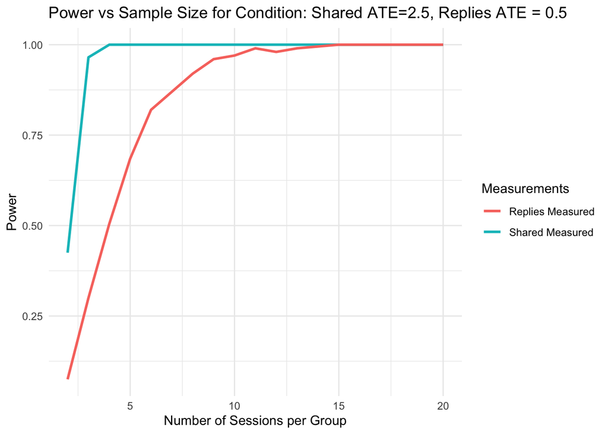

```r
# General function to compute and plot power vs. sample size
compute_power_plot <- function(d, number_of_sessions_per_group, conditionTitle="No Title", power_repeats = 200) {
  power_shared <- numeric(length(number_of_sessions_per_group))
  power_replies <- numeric(length(number_of_sessions_per_group))

  for (j in seq_along(number_of_sessions_per_group)) {
    samples <- number_of_sessions_per_group[j]

    p_values_shared <- numeric(power_repeats)
    p_values_replies <- numeric(power_repeats)

    for (k in 1:power_repeats) {

      sub_sample <- rbindlist(list(
        d[treatment == 1, ][sample(1:.N, samples, replace = FALSE), ],
        d[treatment == 0, ][sample(1:.N, samples, replace = FALSE), ]
      ))

      #t-test for shared_measured
      t_test_shared <- t.test(shared_measured ~ treatment, data = sub_sample)
      p_values_shared[k] <- t_test_shared$p.value

      #t-test for replies_measured
      t_test_replies <- t.test(replies_measured ~ treatment, data = sub_sample)
      p_values_replies[k] <- t_test_replies$p.value
    }

    power_shared[j] <- mean(p_values_shared < 0.05)
    power_replies[j] <- mean(p_values_replies < 0.05)
  }

  # Create a data frame for plotting
  power_data <- data.table(
    Sample_Size = number_of_sessions_per_group,
    Power_Shared = power_shared,
    Power_Replies = power_replies
  )

  # Plotting
  ggplot(power_data, aes(x = Sample_Size)) +
    geom_line(aes(y = Power_Shared, color = "Shared Measured"), size = 1) +
    geom_line(aes(y = Power_Replies, color = "Replies Measured"), size = 1) +
    labs(
      title = conditionTitle,
      x = "Number of Sessions per Group",
      y = "Power",
      color = "Measurements"
    ) +
    theme_minimal()
}


number_of_sessions_per_group <- seq(2, 20, by = 1)


compute_power_plot(d, number_of_sessions_per_group, conditionTitle="Power vs Sample Size for Condition: Shared ATE=2.5, Replies ATE = 0.5")
```

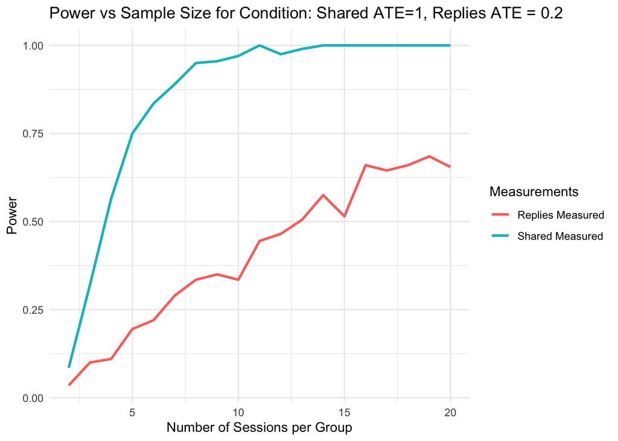

```r
compute_power_plot(e, number_of_sessions_per_group, conditionTitle="Power vs Sample Size for Condition: Shared ATE=1, Replies ATE = 0.2")
```

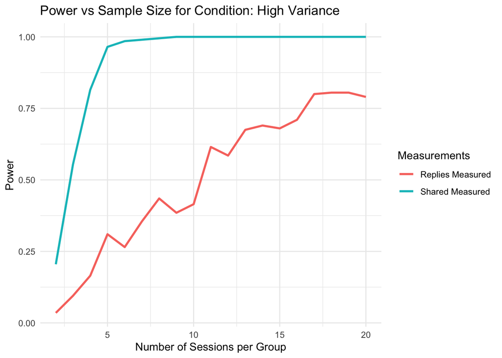

```r
compute_power_plot(c, number_of_sessions_per_group, conditionTitle="Power vs Sample Size for Condition: High Variance")
```

##Old code for performing random inference / without general function, too costly

```r
#
#d[, shared_flyers_treatment := shared_flyers_control + rnorm(demo_size, 1, 0.25) ]
#d[, replies_treatment := replies_control + rnorm(demo_size, 0.5, 0.2)  ]

#d[, shared_measured := ifelse(treatment == 1, shared_flyers_treatment, shared_flyers_control)]
#d[, replies_measured := ifelse(treatment == 1, replies_treatment, replies_control)]

# min all measurements to zero
#d[, shared_measured := pmax(shared_measured, 0)]
#d[, replies_measured := pmax(replies_measured, 0)]

#number_of_sessions_per_group <- seq(3, 20, by = 2)
#power_shared <- numeric(length(number_of_sessions_per_group))
#power_replies <- numeric(length(number_of_sessions_per_group))

#for (j in seq_along(number_of_sessions_per_group)) {
  #samples <- number_of_sessions_per_group[j]

  #power_repeats <- 100
  #p_values_shared <- numeric(power_repeats)
  #p_values_replies <- numeric(power_repeats)

  #for (k in 1:power_repeats) {

    #sub_sample <- rbindlist(list(
   #   d[treatment == 1, ][sample(1:.N, samples, replace = FALSE), ],
    #  d[treatment == 0, ][sample(1:.N, samples, replace = FALSE), ]
    #))


    #Random inference. This would be nice, but takes way too much time to run. Using t-tests (above) instead
    #shared_measured_ate <- mean(sub_sample[treatment == 1]$shared_measured) - mean(sub_sample[treatment == 0]$shared_measured)
    #replies_measured_ate <- mean(sub_sample[treatment == 1]$replies_measured) - mean(sub_sample[treatment == 0]$replies_measured)

    #res_shared <- numeric(1000)
    #res_replies <- numeric(1000)

    #for (i in 1:1000) {
      #balanced_random_treatment <- sample(rep(0:1, each = nrow(sub_sample) / 2))

      #sub_sample[, random_treatment := balanced_random_treatment]

    # ri_means_shared <- sub_sample[, .(ri_mean_shared = mean(shared_measured)), keyby = .(random_treatment)]
    # ri_means_replies <- sub_sample[, .(ri_mean_replies = mean(replies_measured)), keyby = .(random_treatment)]

     #res_shared[i] <- diff(ri_means_shared$ri_mean_shared)
    # res_replies[i] <- diff(ri_means_replies$ri_mean_replies)
    #}

     #Performing a two-tailed p-value test
    #p_values_shared[k] <- mean(abs(res_shared) >= abs(shared_measured_ate))
    #p_values_replies[k] <- mean(abs(res_replies) >= abs(replies_measured_ate))
 # }

  # Calculating power
 # power_shared[j] <- mean(p_values_shared < 0.05)
 # power_replies[j] <- mean(p_values_replies < 0.05)
#}

#print(power_shared)
#print(power_replies)
```